# 使用情緒字典針對PTT nCov2019版做情緒分析

陳韻卉

# 系統參數設定

```r
Sys.setlocale(category = "LC_ALL", locale = "zh_TW.UTF-8") # 避免中文亂碼
```

```
## [1] ""
```

## 安裝需要的packages

```r
packages = c("dplyr", "tidytext", "stringr", "wordcloud2", "ggplot2",'readr','data.table','reshape2','wordcloud','tidyr','scales')
existing = as.character(installed.packages()[,1])
for(pkg in packages[!(packages %in% existing)]) install.packages(pkg)
```

```r
library(dplyr)
```

```r
library(stringr)
library(tidytext)
library(wordcloud2)
library(data.table)
library(ggplot2)
library(reshape2)
library(wordcloud)
library(tidyr)
library(readr)
library(scales)
```

## 資料來源: 文字平台收集PTT nCoV2019版2020-01-25 ~ 2020-03-20 所有文章

資料集: corona_artWordFreq.csv

```r
data = fread('../data/corona_artWordFreq.csv',encoding = 'UTF-8')
```

查看資料前幾筆(已經整理成文章-詞彙-詞頻)

```r
head(data)
```

| artTitle | artDate | artTime | artUrl | word | count |
| --- | --- | --- | --- | --- | --- |
| [新聞]澎湖傳疑似感染武漢肺炎4人負壓病房隔 | 2020/01/25 | 20:28:07 | https://www.ptt.cc/bbs/nCoV2019/M.1579984089.A.535.html | 澎湖 | 7 |
| [新聞]澎湖傳疑似感染武漢肺炎4人負壓病房隔 | 2020/01/25 | 20:28:07 | https://www.ptt.cc/bbs/nCoV2019/M.1579984089.A.535.html | 通報 | 4 |
| [新聞]澎湖傳疑似感染武漢肺炎4人負壓病房隔 | 2020/01/25 | 20:28:07 | https://www.ptt.cc/bbs/nCoV2019/M.1579984089.A.535.html | 女性 | 4 |
| [新聞]澎湖傳疑似感染武漢肺炎4人負壓病房隔 | 2020/01/25 | 20:28:07 | https://www.ptt.cc/bbs/nCoV2019/M.1579984089.A.535.html | 分院 | 3 |
| [新聞]澎湖傳疑似感染武漢肺炎4人負壓病房隔 | 2020/01/25 | 20:28:07 | https://www.ptt.cc/bbs/nCoV2019/M.1579984089.A.535.html | 武漢 | 3 |
| [新聞]澎湖傳疑似感染武漢肺炎4人負壓病房隔 | 2020/01/25 | 20:28:07 | https://www.ptt.cc/bbs/nCoV2019/M.1579984089.A.535.html | 避免 | 3 |

過濾特殊字元

```r
data = data %>%
  filter(!grepl('_',word))
```

轉換日期格式

```r
data$artDate= data$artDate %>% as.Date("%Y/%m/%d")
```

### 計算所有字在文集中的總詞頻

```r
word_count <- data %>%
  select(word,count) %>%
  group_by(word) %>%
  summarise(count = sum(count))  %>%
  filter(count>3) %>%  # 過濾出現太少次的字
  arrange(desc(count))
```

```r
word_count
```

| word | count |
| --- | --- |
| 武漢 | 8630 |
| 肺炎 | 8512 |
| 疫情 | 8456 |
| 確診 | 7913 |
| 口罩 | 7251 |
| 感染 | 6489 |
| 中國 | 6372 |
| 發稿 | 5316 |
| 病毒 | 5240 |
| 台灣 | 4841 |

[output cut: 9990 more lines]

## 準備LIWC字典

> 全名Linguistic Inquiry and Word Counts，由心理學家Pennebaker於2001出版

### 以LIWC字典判斷文集中的word屬於正面字還是負面字

```r
# 正向字典txt檔
# 以,將字分隔
P <- read_file("../dict/liwc/positive.txt")

# 負向字典txt檔
N <- read_file("../dict/liwc/negative.txt")
```

```r
#字典txt檔讀進來是一個字串
typeof(P)
```

```
## [1] "character"
```

```r
#將字串依,分割
#strsplit回傳list , 我們取出list中的第一個元素
P = strsplit(P, ",")[[1]]
N = strsplit(N, ",")[[1]]

# 建立dataframe 有兩個欄位word,sentiments，word欄位內容是字典向量
P = data.frame(word = P, sentiment = "positive")
N = data.frame(word = N, sentiment = "negative")
```

```r
LIWC = rbind(P, N)
```

```r
head(LIWC)
```

|  | word | sentiment |
| --- | --- | --- |
| 1 | 一流 | positive |
| 2 | 下定決心 | positive |
| 3 | 不拘小節 | positive |
| 4 | 不費力 | positive |
| 5 | 不錯 | positive |
| 6 | 主動 | positive |

### 與LIWC情緒字典做join

> 文集中的字出現在LIWC字典中是屬於positive還是negative

```r
word_count %>% inner_join(LIWC)
```

| word | count | sentiment |
| --- | --- | --- |
| 隔離 | 4464 | negative |
| 死亡 | 1989 | negative |
| 問題 | 1620 | negative |
| 治療 | 1480 | positive |
| 健康 | 1337 | positive |
| 流行 | 1304 | positive |
| 嚴重 | 1249 | negative |
| 爆發 | 1190 | negative |
| 希望 | 1070 | positive |
| 風險 | 986 | negative |

[output cut: 674 more lines]

```r
data %>%
  select(word) %>%
  inner_join(LIWC)
```

| word | sentiment |
| --- | --- |
| 自由 | positive |
| 主動 | positive |
| 開心 | positive |
| 嚴重 | negative |
| 健康 | positive |
| 慶祝 | positive |
| 希望 | positive |
| 緊張 | negative |
| 解決 | positive |
| 死亡 | negative |

[output cut: 9990 more lines]

#以LIWC情緒字典分析

#### 統計每天的文章正面字的次數與負面字的次數

```r
sentiment_count = data %>%
  select(artDate,word,count) %>%
  inner_join(LIWC) %>%
  group_by(artDate,sentiment) %>%
  summarise(count=sum(count))
```

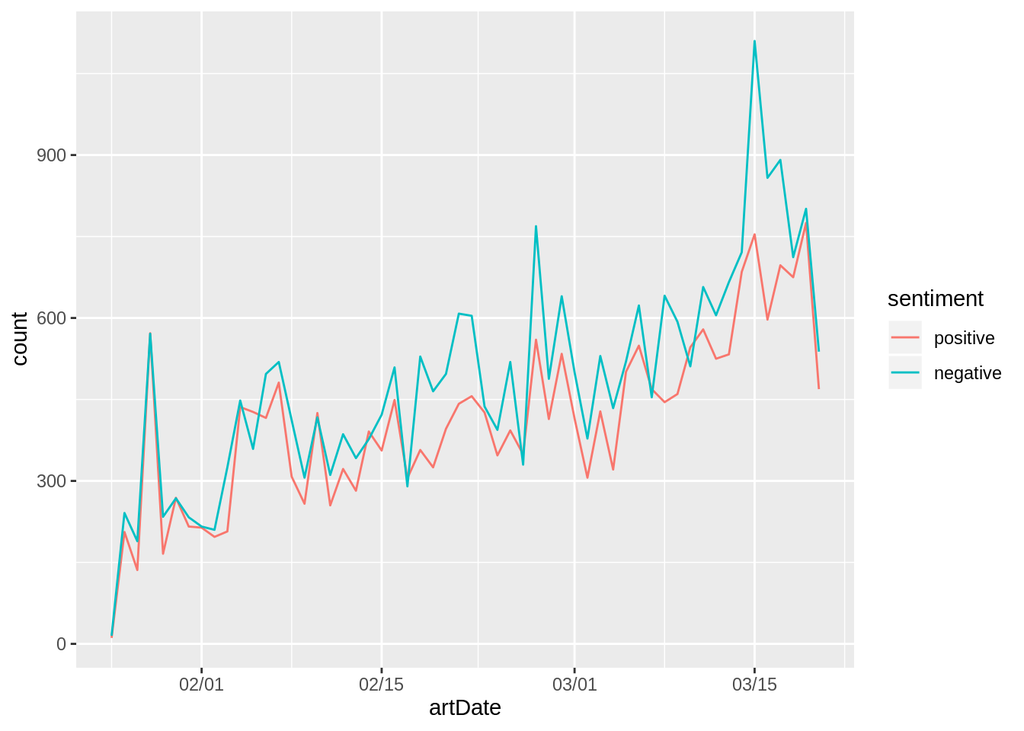

```r
sentiment_count %>%
  ggplot()+
  geom_line(aes(x=artDate,y=count,colour=sentiment))+
  scale_x_date(labels = date_format("%m/%d"))
```

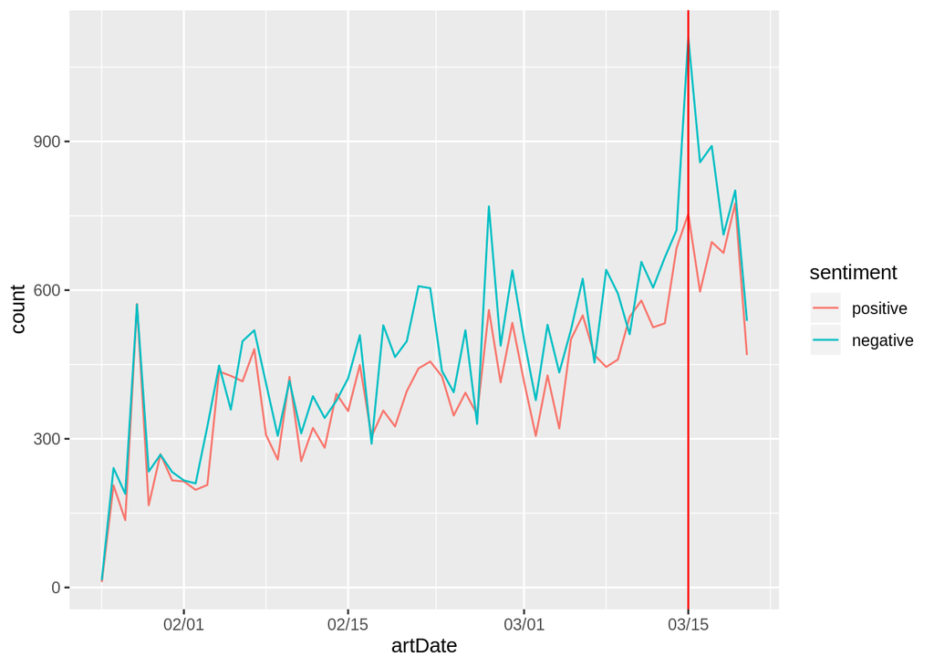

```r
sentiment_count %>%
  ggplot()+
  geom_line(aes(x=artDate,y=count,colour=sentiment))+
  scale_x_date(labels = date_format("%m/%d"))+
  geom_vline(aes(xintercept = as.numeric(artDate[which(sentiment_count$artDate == as.Date('2020/03/15'))
[1]])),colour = "red")
```

```r
#geom_vline畫出vertical line，xintercept告訴他要在artDate欄位的哪一個row畫線
```

> 透過觀察情緒變化來回顧事件內容

```r
data %>% filter(artDate == as.Date('2020/03/15')) %>% distinct(artUrl, .keep_all = TRUE)
```

| artTitle | artDate | artTime | artUrl | word | count |
| --- | --- | --- | --- | --- | --- |
| [新聞]川普檢測結果:陰性 | 2020-03-15 | 00:08:34 | https://www.ptt.cc/bbs/nCoV2019/M.1584230916.A.8CB.html | 發稿 | 2 |
| [新聞]西班牙首相之妻確診 | 2020-03-15 | 01:11:18 | https://www.ptt.cc/bbs/nCoV2019/M.1584234681.A.EA6.html | 首相 | 3 |
| Re:[新聞]藥師忙碌給錯健保卡 婦人飆罵逼「下跪磕 | 2020-03-15 | 01:30:21 | https://www.ptt.cc/bbs/nCoV2019/M.1584235823.A.B79.html | 藥師 | 4 |
| [新聞]確診男坐沙發2分鐘…女接著坐下竟慘被傳 | 2020-03-15 | 01:54:32 | https://www.ptt.cc/bbs/nCoV2019/M.1584237276.A.262.html | 男子 | 6 |
| Re:[情報]0314CECC疫情指揮中心記者會摘要 | 2020-03-15 | 01:59:03 | https://www.ptt.cc/bbs/nCoV2019/M.1584237545.A.FC0.html | 隨機 | 2 |
| [新聞]中藥茶飲抗疫加強免疫力 | 2020-03-15 | 02:05:12 | https://www.ptt.cc/bbs/nCoV2019/M.1584237915.A.65B.html | 體質 | 6 |
| Re:[情報]環球時報社評：瑞典向新冠病毒投降將害人 | 2020-03-15 | 02:23:14 | https://www.ptt.cc/bbs/nCoV2019/M.1584238997.A.53D.html | 支那 | 4 |
| [討論]居家檢疫的執行面沒問題嗎？ | 2020-03-15 | 02:27:15 | https://www.ptt.cc/bbs/nCoV2019/M.1584239237.A.897.html | 檢疫 | 4 |
| [討論]口罩對健康人真的沒有用嗎? | 2020-03-15 | 03:02:20 | https://www.ptt.cc/bbs/nCoV2019/M.1584241342.A.4BA.html | 口罩 | 4 |
| [新聞]巴西港口郵輪「銀幻號」78歲翁確診！ | 2020-03-15 | 03:04:52 | https://www.ptt.cc/bbs/nCoV2019/M.1584241494.A.1CD.html | 巴西 | 6 |

[output cut: 208 more lines]

```r
data %>%
  filter(artDate == as.Date('2020/03/15')) %>%
  select(word,count) %>%
  group_by(word) %>%
  summarise(count = sum(count))  %>%
  filter(count>20) %>%   # 過濾出現太少次的字
  wordcloud2()
```

[interactive chart not shown]

沒有篩選內容的文字雲內容太廣泛，並沒有辦法讓我們聚焦在想觀察的事件

> 哪篇文章的負面情緒最多？負面情緒的字是？

```r
data %>%
  filter(artDate == as.Date('2020/03/15')) %>%
  inner_join(LIWC) %>%
  filter(sentiment == "negative") %>%
  group_by(artUrl,sentiment) %>%
  summarise(
    artTitle = artTitle[1],
    count = n()
  ) %>%
  arrange(desc(count))
```

| artUrl | sentiment | artTitle | count |
| --- | --- | --- | --- |
| https://www.ptt.cc/bbs/nCoV2019/M.1584266005.A.91D.html | negative | [新聞]美國防疫遺忘的「街友感染危機」 | 31 |
| https://www.ptt.cc/bbs/nCoV2019/M.1584271246.A.641.html | negative | Re:[問題]三月份還出國旅遊真的很自私？ | 24 |
| https://www.ptt.cc/bbs/nCoV2019/M.1584241837.A.73A.html | negative | Re:[新聞]紐時：中國為西方贏得時間西方卻浪費了它 | 21 |
| https://www.ptt.cc/bbs/nCoV2019/M.1584267452.A.A1B.html | negative | [情報]0315CECC疫情指揮中心記者會摘要 | 17 |
| https://www.ptt.cc/bbs/nCoV2019/M.1584288366.A.89E.html | negative | [新聞]疫情下傳中國官方要求“停止妖魔化外國” | 16 |
| https://www.ptt.cc/bbs/nCoV2019/M.1584268019.A.E94.html | negative | [情報]0315CECC疫情指揮中心記者會摘要 | 14 |
| https://www.ptt.cc/bbs/nCoV2019/M.1584251035.A.537.html | negative | [新聞]矽谷防疫亂象：改在家上班人潮湧進賣場 | 13 |
| https://www.ptt.cc/bbs/nCoV2019/M.1584273545.A.BB3.html | negative | Re:[問題]三月份還出國旅遊真的很自私？ | 13 |
| https://www.ptt.cc/bbs/nCoV2019/M.1584248882.A.1BB.html | negative | Re:[討論]健康人戴口罩真的沒有用嗎? | 12 |
| https://www.ptt.cc/bbs/nCoV2019/M.1584260427.A.CA6.html | negative | Re:[問題]三月份還出國旅遊真的很自私？ | 11 |

[output cut: 174 more lines]

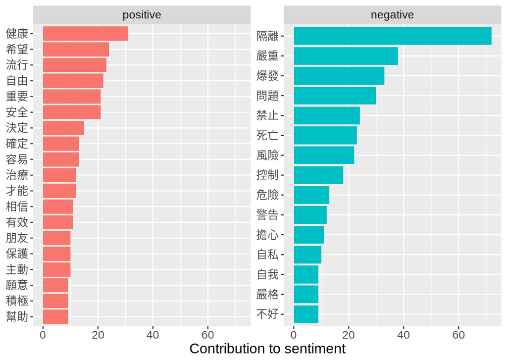

```r
data %>%
  filter(artDate == as.Date('2020/03/15')) %>%
  inner_join(LIWC) %>%
  group_by(word,sentiment) %>%
  summarise(
    count = n()
  ) %>% data.frame() %>%
  top_n(30,wt = count) %>%
  ungroup() %>%
  mutate(word = reorder(word, count)) %>%
  ggplot(aes(word, count, fill = sentiment)) +
  geom_col(show.legend = FALSE) +
  facet_wrap(~sentiment, scales = "free_y") +
  labs(y = "Contribution to sentiment",
       x = NULL) +
  theme(text=element_text(size=14))+
  coord_flip()
```

觀察前後一天的狀況

```r
data %>%
  filter(artDate %in% c(as.Date('2020/03/14'))) %>%
  inner_join(LIWC) %>%
  filter(sentiment == "negative") %>%
  group_by(artUrl,sentiment) %>%
  summarise(
    artTitle = artTitle[1],
    count = n()
  ) %>%
  arrange(desc(count))
```

| artUrl | sentiment | artTitle | count |
| --- | --- | --- | --- |
| https://www.ptt.cc/bbs/nCoV2019/M.1584200770.A.580.html | negative | [新聞]紐時：中國為西方贏得時間西方卻浪費了它 | 38 |
| https://www.ptt.cc/bbs/nCoV2019/M.1584153192.A.6F7.html | negative | Re:[情報]英國專家：群體免疫需感染60%國民 | 25 |
| https://www.ptt.cc/bbs/nCoV2019/M.1584173259.A.687.html | negative | [新聞]經濟學人流行病政治學 | 25 |
| https://www.ptt.cc/bbs/nCoV2019/M.1584170062.A.525.html | negative | [新聞]馬尼拉封城30天，杜特蒂：謝謝習近平 | 18 |
| https://www.ptt.cc/bbs/nCoV2019/M.1584228454.A.F35.html | negative | [情報]環球時報社評：瑞典向新冠病毒投降將害人 | 15 |
| https://www.ptt.cc/bbs/nCoV2019/M.1584156975.A.8EC.html | negative | [新聞]護理師接武漢台人…摘口罩「臉全壓痕」 | 12 |
| https://www.ptt.cc/bbs/nCoV2019/M.1584166425.A.79B.html | negative | [情報]東奧延辦誰說了算？病毒賽跑鈔票，贊助商砌成的「東京奧 | 12 |
| https://www.ptt.cc/bbs/nCoV2019/M.1584181300.A.2F3.html | negative | [情報]為什麼「別讓聯合國等於中國」，現在變得 | 12 |
| https://www.ptt.cc/bbs/nCoV2019/M.1584223910.A.DAC.html | negative | Re:[新聞]紐時：中國為西方贏得時間西方卻浪費了它 | 11 |
| https://www.ptt.cc/bbs/nCoV2019/M.1584156763.A.FD8.html | negative | [新聞]蘋論：疫情全球釀災中國厚顏卸責 | 10 |

[output cut: 113 more lines]

```r
data %>%
  filter(artDate %in% c(as.Date('2020/03/16'))) %>%
  inner_join(LIWC) %>%
  filter(sentiment == "negative") %>%
  group_by(artUrl,sentiment) %>%
  summarise(
    artTitle = artTitle[1],
    count = n()
  ) %>%
  arrange(desc(count))
```

| artUrl | sentiment | artTitle | count |
| --- | --- | --- | --- |
| https://www.ptt.cc/bbs/nCoV2019/M.1584333158.A.046.html | negative | Fw:[爆卦]PTT創世神:英首相要讓大家多染病是假新聞 | 34 |
| https://www.ptt.cc/bbs/nCoV2019/M.1584345514.A.01D.html | negative | [情報]0316CECC疫情指揮中心記者會摘要 | 24 |
| https://www.ptt.cc/bbs/nCoV2019/M.1584340759.A.BA9.html | negative | [新聞]南韓「教會疫情」再次威脅首都圈：城南 | 15 |
| https://www.ptt.cc/bbs/nCoV2019/M.1584352503.A.46E.html | negative | Re:[情報]新增8確診個案，均於國外被感染 | 12 |
| https://www.ptt.cc/bbs/nCoV2019/M.1584331133.A.98C.html | negative | Re:[討論]歐洲各國學生急於返台，台灣該如何應對? | 11 |
| https://www.ptt.cc/bbs/nCoV2019/M.1584332935.A.199.html | negative | [新聞]看不慣英國和瑞士佛系防疫星國部長: | 11 |
| https://www.ptt.cc/bbs/nCoV2019/M.1584362230.A.3AC.html | negative | [新聞]美國律師提集體訟訴狀告中國引發武漢肺 | 11 |
| https://www.ptt.cc/bbs/nCoV2019/M.1584381001.A.DBD.html | negative | [新聞]美國律師提集體訴訟狀告中國引發武漢新 | 11 |
| https://www.ptt.cc/bbs/nCoV2019/M.1584364684.A.246.html | negative | [情報]英國金融時報即時追蹤圖 | 9 |
| https://www.ptt.cc/bbs/nCoV2019/M.1584324712.A.253.html | negative | [情報]俄國有63人確診官員：將爆發社區感染 | 8 |

[output cut: 161 more lines]

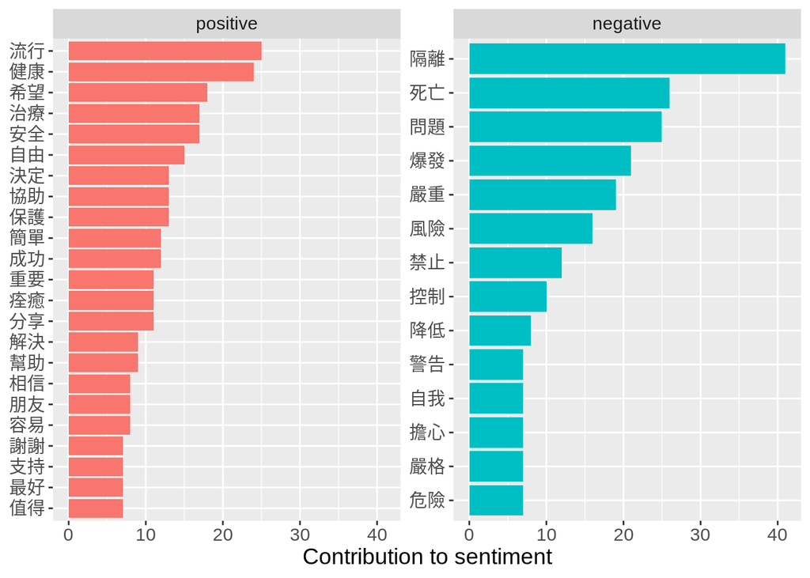

```r
data %>%
  filter(artDate == as.Date('2020/03/14')) %>%
  inner_join(LIWC) %>%
  group_by(word,sentiment) %>%
  summarise(
    count = n()
  ) %>% data.frame() %>%
  top_n(30,wt = count) %>%
  ungroup() %>%
  mutate(word = reorder(word, count)) %>%
  ggplot(aes(word, count, fill = sentiment)) +
  geom_col(show.legend = FALSE) +
  facet_wrap(~sentiment, scales = "free_y") +
  labs(y = "Contribution to sentiment",
       x = NULL) +
  theme(text=element_text(size=14))+
  coord_flip()
```

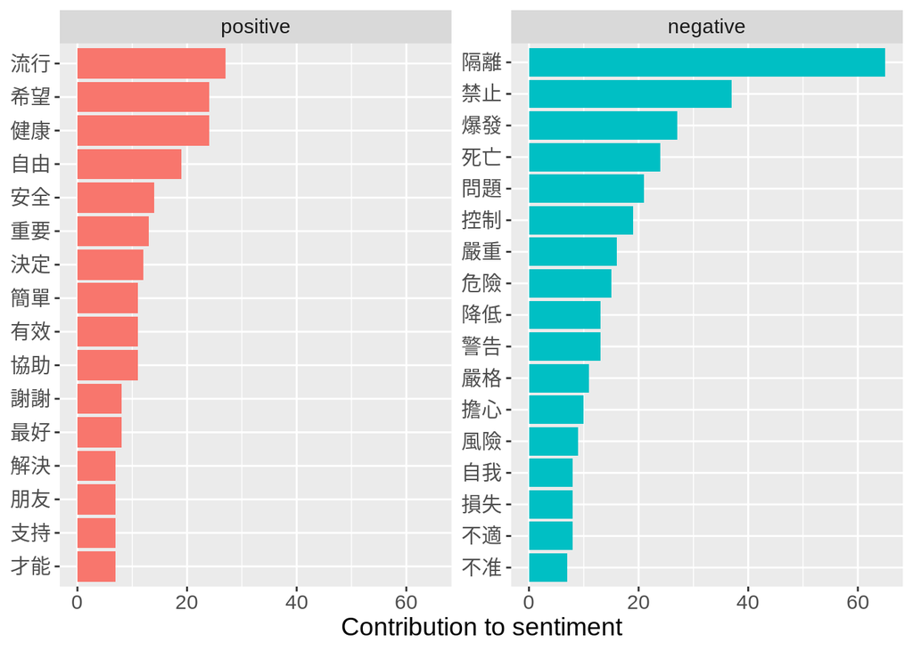

```r
data %>%
  filter(artDate == as.Date('2020/03/16')) %>%
  inner_join(LIWC) %>%
  group_by(word,sentiment) %>%
  summarise(
    count = n()
  ) %>% data.frame() %>%
  top_n(30,wt = count) %>%
  ungroup() %>%
  mutate(word = reorder(word, count)) %>%
  ggplot(aes(word, count, fill = sentiment)) +
  geom_col(show.legend = FALSE) +
  facet_wrap(~sentiment, scales = "free_y") +
  labs(y = "Contribution to sentiment",
       x = NULL) +
  theme(text=element_text(size=14))+
  coord_flip()
```

> 隔離、死亡、嚴重等是疫情常見負面字眼，「自私」是15號與前後一天不同的字詞。可觀察到在15號Po文較前後一天特別聚焦在此負面話題。

## 分析各國的情緒

### 國家名字資料集

```r
country = fread('../data/country.csv',encoding = 'UTF-8')
colnames(country)[1] = "country"
```

將臺灣/台灣統一成臺灣，方便後續篩選

```r
data$word[which(data$word == "台灣")] = "臺灣"
```

將同一篇的斷詞整理在一起

```r
data_full = data %>% select(artUrl,word) %>%
                group_by(artUrl) %>%
                summarise(sentence = paste0(word, collapse = " "))
```

### 台灣

> 只選擇文章中指出現指定國名、不出現其他國名的文章。因為如果一篇文章中出現多個國名，目前無法判斷情緒是針對哪個國家

```r
# 要排除的國名
exclude = paste(country$country[country$country != "臺灣"],collapse="|")

# 要
taiwan = data_full$artUrl[!grepl(exclude, data_full$sentence) & grepl("臺灣", data_full$sentence)]
```

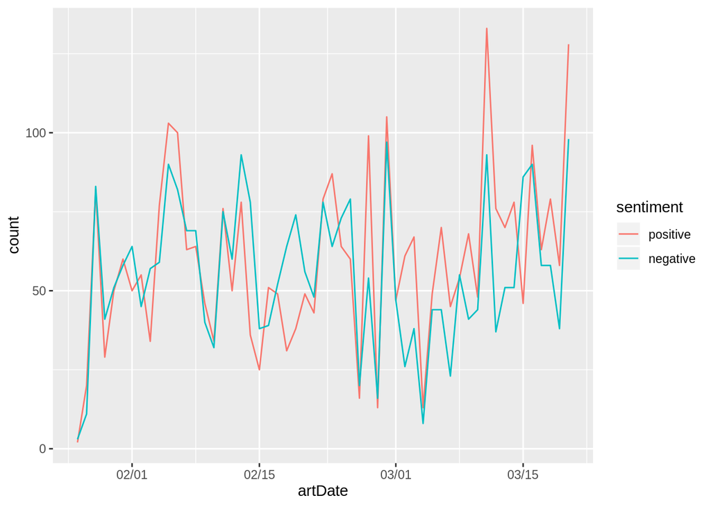

```r
data %>% filter(artUrl %in% taiwan) %>%
  select(artDate,word,count) %>%
  inner_join(LIWC) %>%
  group_by(artDate,sentiment) %>%
  summarise(count=sum(count)) %>%
  ggplot()+
  geom_line(aes(x=artDate,y=count,colour=sentiment))+
  scale_x_date(labels = date_format("%m/%d"))
```

### 中國

```r
exclude = paste(country$country[country$country != "中國"],collapse="|")
china = data_full$artUrl[!grepl(exclude, data_full$sentence) & grepl("中國", data_full$sentence)]
```

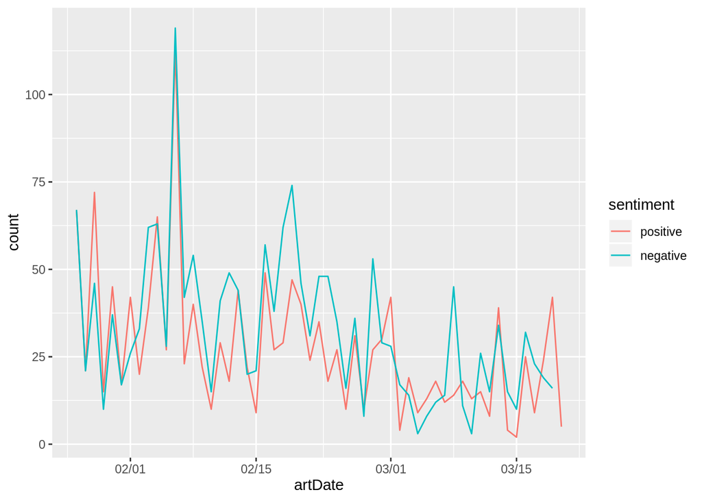

```r
data %>% filter(artUrl %in% china) %>%
  select(artDate,word,count) %>%
  inner_join(LIWC) %>%
  group_by(artDate,sentiment) %>%
  summarise(count=sum(count)) %>%
  ggplot()+
  geom_line(aes(x=artDate,y=count,colour=sentiment))+
  scale_x_date(labels = date_format("%m/%d"))
```

```r
chinaData = data %>% filter(artUrl %in% china) %>%
  select(artDate,word,count) %>%
  inner_join(LIWC) %>%
  filter(sentiment == "negative") %>%
  group_by(artDate,sentiment) %>%
  summarise(count=sum(count))
#中國在哪一天的負面情緒達到最高
chinaData$artDate[which.max(chinaData$count[chinaData$sentiment == "negative"])]
```

```
## [1] "2020-02-06"
```

```r
data %>% filter(artUrl %in% china) %>%
  group_by(artDate,artUrl) %>%
  summarise() %>%
  group_by(artDate) %>%
  summarise(
    count = n()
  )
```

| artDate | count |
| --- | --- |
| 2020-01-26 | 14 |
| 2020-01-27 | 10 |
| 2020-01-28 | 10 |
| 2020-01-29 | 5 |
| 2020-01-30 | 7 |
| 2020-01-31 | 6 |
| 2020-02-01 | 8 |
| 2020-02-02 | 4 |
| 2020-02-03 | 11 |
| 2020-02-04 | 15 |

[output cut: 45 more lines]

> 中國在2/6的討論篇數並不特別多，有可能是內容文字比較多

### 韓國

```r
exclude = paste(country$country[country$country != "韓國"],collapse="|")
korea = data_full$artUrl[!grepl(exclude, data_full$sentence) & grepl("韓國", data_full$sentence)]
```

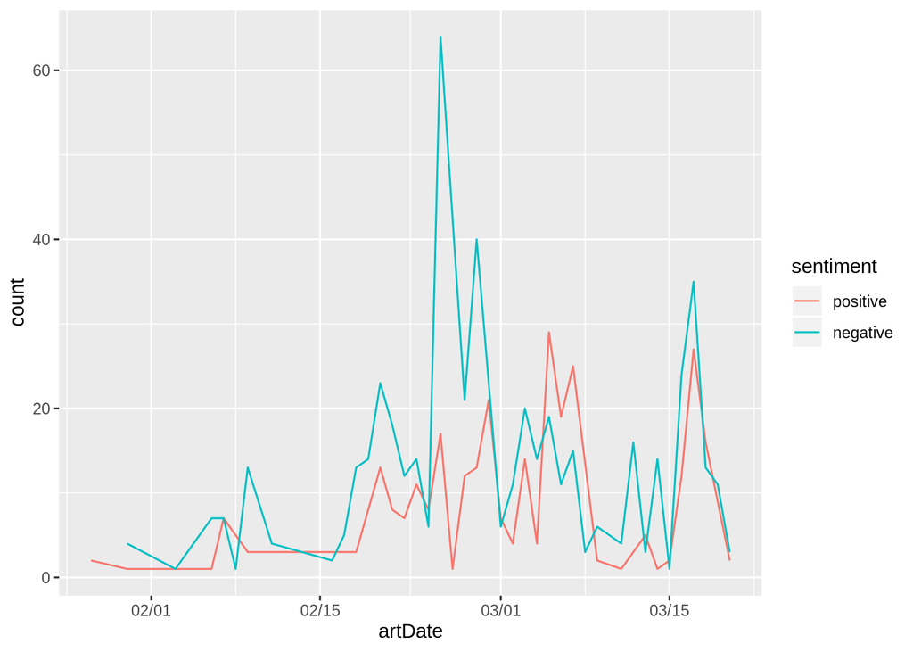

```r
data %>% filter(artUrl %in% korea) %>%
  select(artDate,word,count) %>%
  inner_join(LIWC) %>%
  group_by(artDate,sentiment) %>%
  summarise(count=sum(count)) %>%
  ggplot()+
  geom_line(aes(x=artDate,y=count,colour=sentiment))+
  scale_x_date(labels = date_format("%m/%d"))
```

```r
koreaData = data %>% filter(artUrl %in% korea) %>%
  select(artDate,word,count) %>%
  inner_join(LIWC) %>%
  filter(sentiment == "negative") %>%
  group_by(artDate,sentiment) %>%
  summarise(count=sum(count))
#韓國在哪一天的負面情緒達到最高
koreaData$artDate[which.max(koreaData$count[koreaData$sentiment == "negative"])]
```

```
## [1] "2020-02-25"
```

> 韓國疫情wiki：https://zh.wikipedia.org/wiki/2019%E5%86%A0%E7%8B%80%E7%97%85%E6%AF%92%E7%97%85%E9%9F%93%E5%9C%8B%E7%96%AB%E6%83%85。自2月25日起，自韓國入境的外籍人士，需進行14天居家檢疫

### 義大利

```r
exclude = paste(country$country[country$country != "義大利"],collapse="|")
italy = data_full$artUrl[!grepl(exclude, data_full$sentence) & grepl("義大利", data_full$sentence)]
```

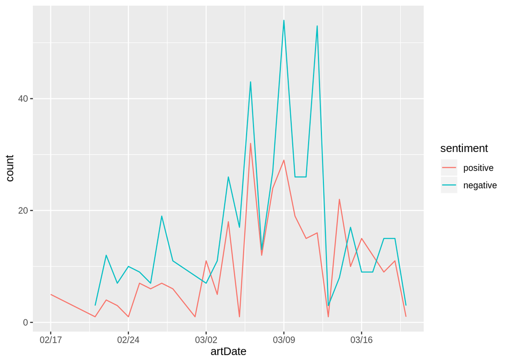

```r
data %>% filter(artUrl %in% italy) %>%
  select(artDate,word,count) %>%
  inner_join(LIWC) %>%
  group_by(artDate,sentiment) %>%
  summarise(count=sum(count)) %>%
  ggplot()+
  geom_line(aes(x=artDate,y=count,colour=sentiment))+
  scale_x_date(labels = date_format("%m/%d"))
```

> 義大利在2月討論聲量低，在3月開始疫情爆發

#### 將各國圖形重疊，利於觀察差別

```r
#新增一欄位紀錄國家類別
data$country = ""
```

```r
data$country[data$artUrl %in% taiwan] = "taiwan"
data$country[data$artUrl %in% china] = "china"
data$country[data$artUrl %in% korea] = "korea"
data$country[data$artUrl %in% italy] = "italy"
```

將正負面情緒分開看

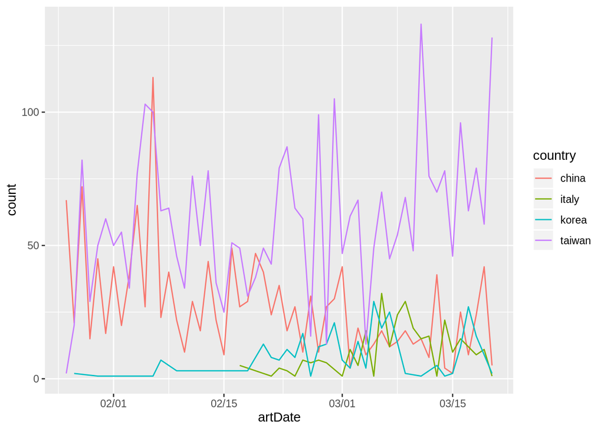

```r
data %>% filter(country != "") %>%
  select(artDate,word,count,country) %>%
  inner_join(LIWC) %>%
  filter(sentiment == "positive") %>%
  group_by(artDate,sentiment,country) %>%
  summarise(count=sum(count)) %>%
  ggplot()+
  geom_line(aes(x=artDate,y=count,colour=country))+
  scale_x_date(labels = date_format("%m/%d"))
```

[figure not shown]

```r
data %>% filter(country != "") %>%
  select(artDate,word,count,country) %>%
  inner_join(LIWC) %>%
  filter(sentiment == "positive") %>%
  group_by(artDate,sentiment,country) %>%
  summarise(count=sum(count)) %>%
  ggplot()+
  geom_line(aes(x=artDate,y=count,colour=country))+
  scale_x_date(labels = date_format("%m/%d"))
```

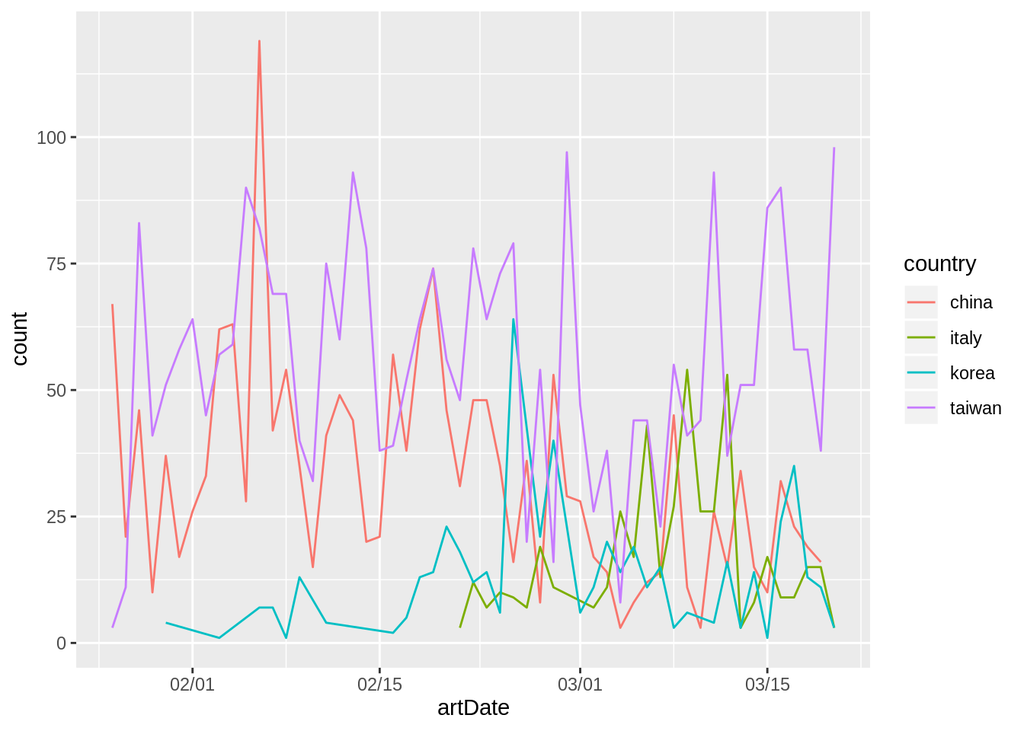

```r
data %>% filter(country != "") %>%
  select(artDate,word,count,country) %>%
  inner_join(LIWC) %>%
  filter(sentiment == "negative") %>%
  group_by(artDate,sentiment,country) %>%
  summarise(count=sum(count)) %>%
  ggplot()+
  geom_line(aes(x=artDate,y=count,colour=country))+
  scale_x_date(labels = date_format("%m/%d"))
```

### 課堂練習

#### 請畫出美國及日本的情緒折線圖，並將他們的正、負面情緒折線圖與各國的圖形重疊